# 4. Pendling mellom de ulike kommunene i regionen.

MSB 106 - Anvendt By- og Regionaløkonomi

```r
suppressPackageStartupMessages({
library(tidyverse)
library(lubridate)
library(PxWebApiData)
library(readr)
library(ggplot2)
})
#knitr::opts_chunk$set(eval=FALSE)
```

# Tabeller for hvert år fra 2000 til 2020

## Tabell for år 2000

```r
Tab_03321_00 <- ApiData(
  urlToData = "03321",
  ArbstedKomm = c(paste0(c(1106, 1135,
                           1145, 1146,
                           1149, 1151,
                           1154, 1159,
                           1211, 1216,
                           1219, 1221,
                           1222, 1223,
                           1224, 1228,
                           1231),
                         ""
                         )
                  ),
  ContentsCode = "Sysselsatte",
  Bokommuen = c(paste0(c(1106, 1135,
                         1145, 1146,
                         1149, 1151,
                         1154, 1159,
                         1211, 1216,
                         1219, 1221,
                         1222, 1223,
                         1224, 1228,
                         1231),
                       ""
                       )
                ),
  Tid = "2000"
  )
```

```r
names(Tab_03321_00)[[1]] <- "desc"
```

```r
Tab_03321_00 <- Tab_03321_00$dataset %>%
  mutate(
    NavnArbstedKomm = Tab_03321_00$desc$arbeidsstedskommune,
    NavnBokommuen = Tab_03321_00$desc$bostedskommune
  ) %>%
  unite("ArbstedKomm", NavnArbstedKomm, ArbstedKomm) %>%
  unite("Bokommuen", NavnBokommuen, Bokommuen) %>%
  select(-ContentsCode, -Tid) %>%
  pivot_wider(
    id_cols = Bokommuen,
    names_from = ArbstedKomm,
    values_from = value
  )
```

# Har endret variabelnavn - sjekk om dette stemmer

```r
Tab_03321_00 <- Tab_03321_00 %>%
  rename(Bokommune = Bokommuen) %>%
  select(-Bokommune) %>%
  mutate(
         Tot_bosted = rowSums(.),
         Tot_arb_komm = colSums(.),
         Ut_pendlere = Tot_bosted - diag(as.matrix(.)),
         Andel_ut_pendlere = round(Ut_pendlere/Tot_bosted*100, 2),
         Inn_pendlere = Tot_arb_komm - diag(as.matrix(.)),
         Andel_inn_pendlere = round(Inn_pendlere/Tot_arb_komm*100, 2),
         Bo_og_arb_komm = Tot_bosted - Ut_pendlere,
         Andel_bo_arb_komm = round(Bo_og_arb_komm/Tot_bosted*100, 2),
         Bokommune = Tab_03321_00$Bokommuen
                    ) %>%
  select(Bokommune, everything())
```

## Tabell for år 2001

```r
Tab_03321_01 <- ApiData(
  urlToData = "03321",
  ArbstedKomm = c(paste0(c(1106, 1135,
                           1145, 1146,
                           1149, 1151,
                           1154, 1159,
                           1211, 1216,
                           1219, 1221,
                           1222, 1223,
                           1224, 1228,
                           1231),
                         ""
                         )
                  ),
  ContentsCode = "Sysselsatte",
  Bokommuen = c(paste0(c(1106, 1135,
                         1145, 1146,
                         1149, 1151,
                         1154, 1159,
                         1211, 1216,
                         1219, 1221,
                         1222, 1223,
                         1224, 1228,
                         1231),
                       ""
                       )
                ),
  Tid = "2001"
  )
```

```r
names(Tab_03321_01)[[1]] <- "desc"
```

```r
Tab_03321_01 <- Tab_03321_01$dataset %>%
  mutate(
    NavnArbstedKomm = Tab_03321_01$desc$arbeidsstedskommune,
    NavnBokommuen = Tab_03321_01$desc$bostedskommune
  ) %>%
  unite("ArbstedKomm", NavnArbstedKomm, ArbstedKomm) %>%
  unite("Bokommuen", NavnBokommuen, Bokommuen) %>%
  select(-ContentsCode, -Tid) %>%
  pivot_wider(
    id_cols = Bokommuen,
    names_from = ArbstedKomm,
    values_from = value
  )
```

```r
Tab_03321_01 <- Tab_03321_01 %>%
  rename(Bokommune = Bokommuen) %>%
  select(-Bokommune) %>%
  mutate(
         Tot_bosted = rowSums(.),
         Pendlere = Tot_bosted - diag(as.matrix(.)),
         Andel_pendlere = round(Pendlere/Tot_bosted*100, 2),
         Tot_arb_komm = colSums(.),
         Arb_inv = Tot_arb_komm - diag(as.matrix(.)),
         Andel_arb_inv = round(Arb_inv/Tot_arb_komm*100, 2),
         Bo_og_arb_komm = Tot_bosted - Pendlere,
         Andel_bo_arb_komm = round(Bo_og_arb_komm/Tot_bosted*100, 2),
         Bokommune = Tab_03321_01$Bokommuen
                    ) %>%
  select(Bokommune, everything())
```

## Tabell for år 2002

```r
Tab_03321_02 <- ApiData(
  urlToData = "03321",
  ArbstedKomm = c(paste0(c(1106, 1135,
                           1145, 1146,
                           1149, 1151,
                           1154, 1159,
                           1211, 1216,
                           1219, 1221,
                           1222, 1223,
                           1224, 1228,
                           1231),
                         ""
                         )
                  ),
  ContentsCode = "Sysselsatte",
  Bokommuen = c(paste0(c(1106, 1135,
                         1145, 1146,
                         1149, 1151,
                         1154, 1159,
                         1211, 1216,
                         1219, 1221,
                         1222, 1223,
                         1224, 1228,
                         1231),
                       ""
                       )
                ),
  Tid = "2002"
  )
```

```r
names(Tab_03321_02)[[1]] <- "desc"
```

```r
Tab_03321_02 <- Tab_03321_02$dataset %>%
  mutate(
    NavnArbstedKomm = Tab_03321_02$desc$arbeidsstedskommune,
    NavnBokommuen = Tab_03321_02$desc$bostedskommune
  ) %>%
  unite("ArbstedKomm", NavnArbstedKomm, ArbstedKomm) %>%
  unite("Bokommuen", NavnBokommuen, Bokommuen) %>%
  select(-ContentsCode, -Tid) %>%
  pivot_wider(
    id_cols = Bokommuen,
    names_from = ArbstedKomm,
    values_from = value
  )
```

```r
Tab_03321_02 <- Tab_03321_02 %>%
  rename(Bokommune = Bokommuen) %>%
  select(-Bokommune) %>%
  mutate(
         Tot_bosted = rowSums(.),
         Pendlere = Tot_bosted - diag(as.matrix(.)),
         Andel_pendlere = round(Pendlere/Tot_bosted*100, 2),
         Tot_arb_komm = colSums(.),
         Arb_inv = Tot_arb_komm - diag(as.matrix(.)),
         Andel_arb_inv = round(Arb_inv/Tot_arb_komm*100, 2),
         Bo_og_arb_komm = Tot_bosted - Pendlere,
         Andel_bo_arb_komm = round(Bo_og_arb_komm/Tot_bosted*100, 2),
         Bokommune = Tab_03321_02$Bokommuen
                    ) %>%
  select(Bokommune, everything())
```

## Tabell for år 2003

```r
Tab_03321_03 <- ApiData(
  urlToData = "03321",
  ArbstedKomm = c(paste0(c(1106, 1135,
                           1145, 1146,
                           1149, 1151,
                           1154, 1159,
                           1211, 1216,
                           1219, 1221,
                           1222, 1223,
                           1224, 1228,
                           1231),
                         ""
                         )
                  ),
  ContentsCode = "Sysselsatte",
  Bokommuen = c(paste0(c(1106, 1135,
                         1145, 1146,
                         1149, 1151,
                         1154, 1159,
                         1211, 1216,
                         1219, 1221,
                         1222, 1223,
                         1224, 1228,
                         1231),
                       ""
                       )
                ),
  Tid = "2003"
  )
```

```r
names(Tab_03321_03)[[1]] <- "desc"
```

```r
Tab_03321_03 <- Tab_03321_03$dataset %>%
  mutate(
    NavnArbstedKomm = Tab_03321_03$desc$arbeidsstedskommune,
    NavnBokommuen = Tab_03321_03$desc$bostedskommune
  ) %>%
  unite("ArbstedKomm", NavnArbstedKomm, ArbstedKomm) %>%
  unite("Bokommuen", NavnBokommuen, Bokommuen) %>%
  select(-ContentsCode, -Tid) %>%
  pivot_wider(
    id_cols = Bokommuen,
    names_from = ArbstedKomm,
    values_from = value
  )
```

```r
Tab_03321_03 <- Tab_03321_03 %>%
  rename(Bokommune = Bokommuen) %>%
  select(-Bokommune) %>%
  mutate(
         Tot_bosted = rowSums(.),
         Pendlere = Tot_bosted - diag(as.matrix(.)),
         Andel_pendlere = round(Pendlere/Tot_bosted*100, 2),
         Tot_arb_komm = colSums(.),
         Arb_inv = Tot_arb_komm - diag(as.matrix(.)),
         Andel_arb_inv = round(Arb_inv/Tot_arb_komm*100, 2),
         Bo_og_arb_komm = Tot_bosted - Pendlere,
         Andel_bo_arb_komm = round(Bo_og_arb_komm/Tot_bosted*100, 2),
         Bokommune = Tab_03321_03$Bokommuen
                    ) %>%
  select(Bokommune, everything())
```

## Tabell for år 2004

```r
Tab_03321_04 <- ApiData(
  urlToData = "03321",
  ArbstedKomm = c(paste0(c(1106, 1135,
                           1145, 1146,
                           1149, 1151,
                           1154, 1159,
                           1211, 1216,
                           1219, 1221,
                           1222, 1223,
                           1224, 1228,
                           1231),
                         ""
                         )
                  ),
  ContentsCode = "Sysselsatte",
  Bokommuen = c(paste0(c(1106, 1135,
                         1145, 1146,
                         1149, 1151,
                         1154, 1159,
                         1211, 1216,
                         1219, 1221,
                         1222, 1223,
                         1224, 1228,
                         1231),
                       ""
                       )
                ),
  Tid = "2004"
  )
```

```r
names(Tab_03321_04)[[1]] <- "desc"
```

```r
Tab_03321_04 <- Tab_03321_04$dataset %>%
  mutate(
    NavnArbstedKomm = Tab_03321_04$desc$arbeidsstedskommune,
    NavnBokommuen = Tab_03321_04$desc$bostedskommune
  ) %>%
  unite("ArbstedKomm", NavnArbstedKomm, ArbstedKomm) %>%
  unite("Bokommuen", NavnBokommuen, Bokommuen) %>%
  select(-ContentsCode, -Tid) %>%
  pivot_wider(
    id_cols = Bokommuen,
    names_from = ArbstedKomm,
    values_from = value
  )
```

```r
Tab_03321_04 <- Tab_03321_04 %>%
  rename(Bokommune = Bokommuen) %>%
  select(-Bokommune) %>%
  mutate(
         Tot_bosted = rowSums(.),
         Pendlere = Tot_bosted - diag(as.matrix(.)),
         Andel_pendlere = round(Pendlere/Tot_bosted*100, 2),
         Tot_arb_komm = colSums(.),
         Arb_inv = Tot_arb_komm - diag(as.matrix(.)),
         Andel_arb_inv = round(Arb_inv/Tot_arb_komm*100, 2),
         Bo_og_arb_komm = Tot_bosted - Pendlere,
         Andel_bo_arb_komm = round(Bo_og_arb_komm/Tot_bosted*100, 2),
         Bokommune = Tab_03321_04$Bokommuen
                    ) %>%
  select(Bokommune, everything())
```

## Tabell for år 2005

```r
Tab_03321_05 <- ApiData(
  urlToData = "03321",
  ArbstedKomm = c(paste0(c(1106, 1135,
                           1145, 1146,
                           1149, 1151,
                           1160,
                           1211, 1216,
                           1219, 1221,
                           1222, 1223,
                           1224, 1228,
                           1231),
                         ""
                         )
                  ),
  ContentsCode = "Sysselsatte",
  Bokommuen = c(paste0(c(1106, 1135,
                         1145, 1146,
                         1149, 1151,
                         1160,
                         1211, 1216,
                         1219, 1221,
                         1222, 1223,
                         1224, 1228,
                         1231),
                       ""
                       )
                ),
  Tid = "2005"
  )
```

```r
names(Tab_03321_05)[[1]] <- "desc"
```

```r
Tab_03321_05 <- Tab_03321_05$dataset %>%
  mutate(
    NavnArbstedKomm = Tab_03321_05$desc$arbeidsstedskommune,
    NavnBokommuen = Tab_03321_05$desc$bostedskommune
  ) %>%
  unite("ArbstedKomm", NavnArbstedKomm, ArbstedKomm) %>%
  unite("Bokommuen", NavnBokommuen, Bokommuen) %>%
  select(-ContentsCode, -Tid) %>%
  pivot_wider(
    id_cols = Bokommuen,
    names_from = ArbstedKomm,
    values_from = value
  )
```

```r
Tab_03321_05 <- Tab_03321_05 %>%
  rename(Bokommune = Bokommuen) %>%
  select(-Bokommune) %>%
  mutate(
         Tot_bosted = rowSums(.),
         Pendlere = Tot_bosted - diag(as.matrix(.)),
         Andel_pendlere = round(Pendlere/Tot_bosted*100, 2),
         Tot_arb_komm = colSums(.),
         Arb_inv = Tot_arb_komm - diag(as.matrix(.)),
         Andel_arb_inv = round(Arb_inv/Tot_arb_komm*100, 2),
         Bo_og_arb_komm = Tot_bosted - Pendlere,
         Andel_bo_arb_komm = round(Bo_og_arb_komm/Tot_bosted*100, 2),
         Bokommune = Tab_03321_05$Bokommuen
                    ) %>%
  select(Bokommune, everything())
```

## Tabell for år 2006

```r
Tab_03321_06 <- ApiData(
  urlToData = "03321",
  ArbstedKomm = c(paste0(c(1106, 1135,
                           1145, 1146,
                           1149, 1151,
                           1160,
                           1211, 1216,
                           1219, 1221,
                           1222, 1223,
                           1224, 1228,
                           1231),
                         ""
                         )
                  ),
  ContentsCode = "Sysselsatte",
  Bokommuen = c(paste0(c(1106, 1135,
                         1145, 1146,
                         1149, 1151,
                         1160,
                         1211, 1216,
                         1219, 1221,
                         1222, 1223,
                         1224, 1228,
                         1231),
                       ""
                       )
                ),
  Tid = "2006"
  )
```

```r
names(Tab_03321_06)[[1]] <- "desc"
```

```r
Tab_03321_06 <- Tab_03321_06$dataset %>%
  mutate(
    NavnArbstedKomm = Tab_03321_06$desc$arbeidsstedskommune,
    NavnBokommuen = Tab_03321_06$desc$bostedskommune
  ) %>%
  unite("ArbstedKomm", NavnArbstedKomm, ArbstedKomm) %>%
  unite("Bokommuen", NavnBokommuen, Bokommuen) %>%
  select(-ContentsCode, -Tid) %>%
  pivot_wider(
    id_cols = Bokommuen,
    names_from = ArbstedKomm,
    values_from = value
  )
```

```r
Tab_03321_06 <- Tab_03321_06 %>%
  rename(Bokommune = Bokommuen) %>%
  select(-Bokommune) %>%
  mutate(
         Tot_bosted = rowSums(.),
         Pendlere = Tot_bosted - diag(as.matrix(.)),
         Andel_pendlere = round(Pendlere/Tot_bosted*100, 2),
         Tot_arb_komm = colSums(.),
         Arb_inv = Tot_arb_komm - diag(as.matrix(.)),
         Andel_arb_inv = round(Arb_inv/Tot_arb_komm*100, 2),
         Bo_og_arb_komm = Tot_bosted - Pendlere,
         Andel_bo_arb_komm = round(Bo_og_arb_komm/Tot_bosted*100, 2),
         Bokommune = Tab_03321_06$Bokommuen
                    ) %>%
  select(Bokommune, everything())
```

## Tabell for år 2007

```r
Tab_03321_07 <- ApiData(
  urlToData = "03321",
  ArbstedKomm = c(paste0(c(1106, 1135,
                           1145, 1146,
                           1149, 1151,
                           1160,
                           1211, 1216,
                           1219, 1221,
                           1222, 1223,
                           1224, 1228,
                           1231),
                         ""
                         )
                  ),
  ContentsCode = "Sysselsatte",
  Bokommuen = c(paste0(c(1106, 1135,
                         1145, 1146,
                         1149, 1151,
                         1160,
                         1211, 1216,
                         1219, 1221,
                         1222, 1223,
                         1224, 1228,
                         1231),
                       ""
                       )
                ),
  Tid = "2007"
  )
```

```r
names(Tab_03321_07)[[1]] <- "desc"
```

```r
Tab_03321_07 <- Tab_03321_07$dataset %>%
  mutate(
    NavnArbstedKomm = Tab_03321_07$desc$arbeidsstedskommune,
    NavnBokommuen = Tab_03321_07$desc$bostedskommune
  ) %>%
  unite("ArbstedKomm", NavnArbstedKomm, ArbstedKomm) %>%
  unite("Bokommuen", NavnBokommuen, Bokommuen) %>%
  select(-ContentsCode, -Tid) %>%
  pivot_wider(
    id_cols = Bokommuen,
    names_from = ArbstedKomm,
    values_from = value
  )
```

```r
Tab_03321_07 <- Tab_03321_07 %>%
  rename(Bokommune = Bokommuen) %>%
  select(-Bokommune) %>%
  mutate(
         Tot_bosted = rowSums(.),
         Pendlere = Tot_bosted - diag(as.matrix(.)),
         Andel_pendlere = round(Pendlere/Tot_bosted*100, 2),
         Tot_arb_komm = colSums(.),
         Arb_inv = Tot_arb_komm - diag(as.matrix(.)),
         Andel_arb_inv = round(Arb_inv/Tot_arb_komm*100, 2),
         Bo_og_arb_komm = Tot_bosted - Pendlere,
         Andel_bo_arb_komm = round(Bo_og_arb_komm/Tot_bosted*100, 2),
         Bokommune = Tab_03321_07$Bokommuen
                    ) %>%
  select(Bokommune, everything())
```

## Tabell for år 2008

```r
Tab_03321_08 <- ApiData(
  urlToData = "03321",
  ArbstedKomm = c(paste0(c(1106, 1135,
                           1145, 1146,
                           1149, 1151,
                           1160,
                           1211, 1216,
                           1219, 1221,
                           1222, 1223,
                           1224, 1228,
                           1231),
                         ""
                         )
                  ),
  ContentsCode = "Sysselsatte",
  Bokommuen = c(paste0(c(1106, 1135,
                         1145, 1146,
                         1149, 1151,
                         1160,
                         1211, 1216,
                         1219, 1221,
                         1222, 1223,
                         1224, 1228,
                         1231),
                       ""
                       )
                ),
  Tid = "2008"
  )
```

```r
names(Tab_03321_08)[[1]] <- "desc"
```

```r
Tab_03321_08 <- Tab_03321_08$dataset %>%
  mutate(
    NavnArbstedKomm = Tab_03321_08$desc$arbeidsstedskommune,
    NavnBokommuen = Tab_03321_08$desc$bostedskommune
  ) %>%
  unite("ArbstedKomm", NavnArbstedKomm, ArbstedKomm) %>%
  unite("Bokommuen", NavnBokommuen, Bokommuen) %>%
  select(-ContentsCode, -Tid) %>%
  pivot_wider(
    id_cols = Bokommuen,
    names_from = ArbstedKomm,
    values_from = value
  )
```

```r
Tab_03321_08 <- Tab_03321_08 %>%
  rename(Bokommune = Bokommuen) %>%
  select(-Bokommune) %>%
  mutate(
         Tot_bosted = rowSums(.),
         Pendlere = Tot_bosted - diag(as.matrix(.)),
         Andel_pendlere = round(Pendlere/Tot_bosted*100, 2),
         Tot_arb_komm = colSums(.),
         Arb_inv = Tot_arb_komm - diag(as.matrix(.)),
         Andel_arb_inv = round(Arb_inv/Tot_arb_komm*100, 2),
         Bo_og_arb_komm = Tot_bosted - Pendlere,
         Andel_bo_arb_komm = round(Bo_og_arb_komm/Tot_bosted*100, 2),
         Bokommune = Tab_03321_08$Bokommuen
                    ) %>%
  select(Bokommune, everything())
```

## Tabell for år 2009

```r
Tab_03321_09 <- ApiData(
  urlToData = "03321",
  ArbstedKomm = c(paste0(c(1106, 1135,
                           1145, 1146,
                           1149, 1151,
                           1160,
                           1211, 1216,
                           1219, 1221,
                           1222, 1223,
                           1224, 1228,
                           1231),
                         ""
                         )
                  ),
  ContentsCode = "Sysselsatte",
  Bokommuen = c(paste0(c(1106, 1135,
                         1145, 1146,
                         1149, 1151,
                         1160,
                         1211, 1216,
                         1219, 1221,
                         1222, 1223,
                         1224, 1228,
                         1231),
                       ""
                       )
                ),
  Tid = "2009"
  )
```

```r
names(Tab_03321_09)[[1]] <- "desc"
```

```r
Tab_03321_09 <- Tab_03321_09$dataset %>%
  mutate(
    NavnArbstedKomm = Tab_03321_09$desc$arbeidsstedskommune,
    NavnBokommuen = Tab_03321_09$desc$bostedskommune
  ) %>%
  unite("ArbstedKomm", NavnArbstedKomm, ArbstedKomm) %>%
  unite("Bokommuen", NavnBokommuen, Bokommuen) %>%
  select(-ContentsCode, -Tid) %>%
  pivot_wider(
    id_cols = Bokommuen,
    names_from = ArbstedKomm,
    values_from = value
  )
```

```r
Tab_03321_09 <- Tab_03321_09 %>%
  rename(Bokommune = Bokommuen) %>%
  select(-Bokommune) %>%
  mutate(
         Tot_bosted = rowSums(.),
         Pendlere = Tot_bosted - diag(as.matrix(.)),
         Andel_pendlere = round(Pendlere/Tot_bosted*100, 2),
         Tot_arb_komm = colSums(.),
         Arb_inv = Tot_arb_komm - diag(as.matrix(.)),
         Andel_arb_inv = round(Arb_inv/Tot_arb_komm*100, 2),
         Bo_og_arb_komm = Tot_bosted - Pendlere,
         Andel_bo_arb_komm = round(Bo_og_arb_komm/Tot_bosted*100, 2),
         Bokommune = Tab_03321_09$Bokommuen
                    ) %>%
  select(Bokommune, everything())
```

## Tabell for år 2010

```r
Tab_03321_10 <- ApiData(
  urlToData = "03321",
  ArbstedKomm = c(paste0(c(1106, 1135,
                           1145, 1146,
                           1149, 1151,
                           1160,
                           1211, 1216,
                           1219, 1221,
                           1222, 1223,
                           1224, 1228,
                           1231),
                         ""
                         )
                  ),
  ContentsCode = "Sysselsatte",
  Bokommuen = c(paste0(c(1106, 1135,
                         1145, 1146,
                         1149, 1151,
                         1160,
                         1211, 1216,
                         1219, 1221,
                         1222, 1223,
                         1224, 1228,
                         1231),
                       ""
                       )
                ),
  Tid = "2010"
  )
```

```r
names(Tab_03321_10)[[1]] <- "desc"
```

```r
Tab_03321_10 <- Tab_03321_10$dataset %>%
  mutate(
    NavnArbstedKomm = Tab_03321_10$desc$arbeidsstedskommune,
    NavnBokommuen = Tab_03321_10$desc$bostedskommune
  ) %>%
  unite("ArbstedKomm", NavnArbstedKomm, ArbstedKomm) %>%
  unite("Bokommuen", NavnBokommuen, Bokommuen) %>%
  select(-ContentsCode, -Tid) %>%
  pivot_wider(
    id_cols = Bokommuen,
    names_from = ArbstedKomm,
    values_from = value
  )
```

```r
Tab_03321_10 <- Tab_03321_10 %>%
  rename(Bokommune = Bokommuen) %>%
  select(-Bokommune) %>%
  mutate(
         Tot_bosted = rowSums(.),
         Pendlere = Tot_bosted - diag(as.matrix(.)),
         Andel_pendlere = round(Pendlere/Tot_bosted*100, 2),
         Tot_arb_komm = colSums(.),
         Arb_inv = Tot_arb_komm - diag(as.matrix(.)),
         Andel_arb_inv = round(Arb_inv/Tot_arb_komm*100, 2),
         Bo_og_arb_komm = Tot_bosted - Pendlere,
         Andel_bo_arb_komm = round(Bo_og_arb_komm/Tot_bosted*100, 2),
         Bokommune = Tab_03321_10$Bokommuen
                    ) %>%
  select(Bokommune, everything())
```

## Tabell for år 2011

```r
Tab_03321_11 <- ApiData(
  urlToData = "03321",
  ArbstedKomm = c(paste0(c(1106, 1135,
                           1145, 1146,
                           1149, 1151,
                           1160,
                           1211, 1216,
                           1219, 1221,
                           1222, 1223,
                           1224, 1228,
                           1231),
                         ""
                         )
                  ),
  ContentsCode = "Sysselsatte",
  Bokommuen = c(paste0(c(1106, 1135,
                         1145, 1146,
                         1149, 1151,
                         1160,
                         1211, 1216,
                         1219, 1221,
                         1222, 1223,
                         1224, 1228,
                         1231),
                       ""
                       )
                ),
  Tid = "2011"
  )
```

```r
names(Tab_03321_11)[[1]] <- "desc"
```

```r
Tab_03321_11 <- Tab_03321_11$dataset %>%
  mutate(
    NavnArbstedKomm = Tab_03321_11$desc$arbeidsstedskommune,
    NavnBokommuen = Tab_03321_11$desc$bostedskommune
  ) %>%
  unite("ArbstedKomm", NavnArbstedKomm, ArbstedKomm) %>%
  unite("Bokommuen", NavnBokommuen, Bokommuen) %>%
  select(-ContentsCode, -Tid) %>%
  pivot_wider(
    id_cols = Bokommuen,
    names_from = ArbstedKomm,
    values_from = value
  )
```

```r
Tab_03321_11 <- Tab_03321_11 %>%
  rename(Bokommune = Bokommuen) %>%
  select(-Bokommune) %>%
  mutate(
         Tot_bosted = rowSums(.),
         Pendlere = Tot_bosted - diag(as.matrix(.)),
         Andel_pendlere = round(Pendlere/Tot_bosted*100, 2),
         Tot_arb_komm = colSums(.),
         Arb_inv = Tot_arb_komm - diag(as.matrix(.)),
         Andel_arb_inv = round(Arb_inv/Tot_arb_komm*100, 2),
         Bo_og_arb_komm = Tot_bosted - Pendlere,
         Andel_bo_arb_komm = round(Bo_og_arb_komm/Tot_bosted*100, 2),
         Bokommune = Tab_03321_11$Bokommuen
                    ) %>%
  select(Bokommune, everything())
```

## Tabell for år 2012

```r
Tab_03321_12 <- ApiData(
  urlToData = "03321",
  ArbstedKomm = c(paste0(c(1106, 1135,
                           1145, 1146,
                           1149, 1151,
                           1160,
                           1211, 1216,
                           1219, 1221,
                           1222, 1223,
                           1224, 1228,
                           1231),
                         ""
                         )
                  ),
  ContentsCode = "Sysselsatte",
  Bokommuen = c(paste0(c(1106, 1135,
                         1145, 1146,
                         1149, 1151,
                         1160,
                         1211, 1216,
                         1219, 1221,
                         1222, 1223,
                         1224, 1228,
                         1231),
                       ""
                       )
                ),
  Tid = "2012"
  )
```

```r
names(Tab_03321_12)[[1]] <- "desc"
```

```r
Tab_03321_12 <- Tab_03321_12$dataset %>%
  mutate(
    NavnArbstedKomm = Tab_03321_12$desc$arbeidsstedskommune,
    NavnBokommuen = Tab_03321_12$desc$bostedskommune
  ) %>%
  unite("ArbstedKomm", NavnArbstedKomm, ArbstedKomm) %>%
  unite("Bokommuen", NavnBokommuen, Bokommuen) %>%
  select(-ContentsCode, -Tid) %>%
  pivot_wider(
    id_cols = Bokommuen,
    names_from = ArbstedKomm,
    values_from = value
  )
```

```r
Tab_03321_12 <- Tab_03321_12 %>%
  rename(Bokommune = Bokommuen) %>%
  select(-Bokommune) %>%
  mutate(
         Tot_bosted = rowSums(.),
         Pendlere = Tot_bosted - diag(as.matrix(.)),
         Andel_pendlere = round(Pendlere/Tot_bosted*100, 2),
         Tot_arb_komm = colSums(.),
         Arb_inv = Tot_arb_komm - diag(as.matrix(.)),
         Andel_arb_inv = round(Arb_inv/Tot_arb_komm*100, 2),
         Bo_og_arb_komm = Tot_bosted - Pendlere,
         Andel_bo_arb_komm = round(Bo_og_arb_komm/Tot_bosted*100, 2),
         Bokommune = Tab_03321_12$Bokommuen
                    ) %>%
  select(Bokommune, everything())
```

## Tabell for år 2013

```r
Tab_03321_13 <- ApiData(
  urlToData = "03321",
  ArbstedKomm = c(paste0(c(1106, 1135,
                           1145, 1146,
                           1149, 1151,
                           1160,
                           1211, 1216,
                           1219, 1221,
                           1222, 1223,
                           1224, 1228,
                           1231),
                         ""
                         )
                  ),
  ContentsCode = "Sysselsatte",
  Bokommuen = c(paste0(c(1106, 1135,
                         1145, 1146,
                         1149, 1151,
                         1160,
                         1211, 1216,
                         1219, 1221,
                         1222, 1223,
                         1224, 1228,
                         1231),
                       ""
                       )
                ),
  Tid = "2013"
  )
```

```r
names(Tab_03321_13)[[1]] <- "desc"
```

```r
Tab_03321_13 <- Tab_03321_13$dataset %>%
  mutate(
    NavnArbstedKomm = Tab_03321_13$desc$arbeidsstedskommune,
    NavnBokommuen = Tab_03321_13$desc$bostedskommune
  ) %>%
  unite("ArbstedKomm", NavnArbstedKomm, ArbstedKomm) %>%
  unite("Bokommuen", NavnBokommuen, Bokommuen) %>%
  select(-ContentsCode, -Tid) %>%
  pivot_wider(
    id_cols = Bokommuen,
    names_from = ArbstedKomm,
    values_from = value
  )
```

```r
Tab_03321_13 <- Tab_03321_13 %>%
  rename(Bokommune = Bokommuen) %>%
  select(-Bokommune) %>%
  mutate(
         Tot_bosted = rowSums(.),
         Pendlere = Tot_bosted - diag(as.matrix(.)),
         Andel_pendlere = round(Pendlere/Tot_bosted*100, 2),
         Tot_arb_komm = colSums(.),
         Arb_inv = Tot_arb_komm - diag(as.matrix(.)),
         Andel_arb_inv = round(Arb_inv/Tot_arb_komm*100, 2),
         Bo_og_arb_komm = Tot_bosted - Pendlere,
         Andel_bo_arb_komm = round(Bo_og_arb_komm/Tot_bosted*100, 2),
         Bokommune = Tab_03321_13$Bokommuen
                    ) %>%
  select(Bokommune, everything())
```

## Tabell for år 2014

```r
Tab_03321_14 <- ApiData(
  urlToData = "03321",
  ArbstedKomm = c(paste0(c(1106, 1135,
                           1145, 1146,
                           1149, 1151,
                           1160,
                           1211, 1216,
                           1219, 1221,
                           1222, 1223,
                           1224, 1228,
                           1231),
                         ""
                         )
                  ),
  ContentsCode = "Sysselsatte",
  Bokommuen = c(paste0(c(1106, 1135,
                         1145, 1146,
                         1149, 1151,
                         1160,
                         1211, 1216,
                         1219, 1221,
                         1222, 1223,
                         1224, 1228,
                         1231),
                       ""
                       )
                ),
  Tid = "2014"
  )
```

```r
names(Tab_03321_14)[[1]] <- "desc"
```

```r
Tab_03321_14 <- Tab_03321_14$dataset %>%
  mutate(
    NavnArbstedKomm = Tab_03321_14$desc$arbeidsstedskommune,
    NavnBokommuen = Tab_03321_14$desc$bostedskommune
  ) %>%
  unite("ArbstedKomm", NavnArbstedKomm, ArbstedKomm) %>%
  unite("Bokommuen", NavnBokommuen, Bokommuen) %>%
  select(-ContentsCode, -Tid) %>%
  pivot_wider(
    id_cols = Bokommuen,
    names_from = ArbstedKomm,
    values_from = value
  )
```

```r
Tab_03321_14 <- Tab_03321_14 %>%
  rename(Bokommune = Bokommuen) %>%
  select(-Bokommune) %>%
  mutate(
         Tot_bosted = rowSums(.),
         Pendlere = Tot_bosted - diag(as.matrix(.)),
         Andel_pendlere = round(Pendlere/Tot_bosted*100, 2),
         Tot_arb_komm = colSums(.),
         Arb_inv = Tot_arb_komm - diag(as.matrix(.)),
         Andel_arb_inv = round(Arb_inv/Tot_arb_komm*100, 2),
         Bo_og_arb_komm = Tot_bosted - Pendlere,
         Andel_bo_arb_komm = round(Bo_og_arb_komm/Tot_bosted*100, 2),
         Bokommune = Tab_03321_14$Bokommuen
                    ) %>%
  select(Bokommune, everything())
```

## Tabell for år 2015

```r
Tab_03321_15 <- ApiData(
  urlToData = "03321",
  ArbstedKomm = c(paste0(c(1106, 1135,
                           1145, 1146,
                           1149, 1151,
                           1160,
                           1211, 1216,
                           1219, 1221,
                           1222, 1223,
                           1224, 1228,
                           1231),
                         ""
                         )
                  ),
  ContentsCode = "Sysselsatte",
  Bokommuen = c(paste0(c(1106, 1135,
                         1145, 1146,
                         1149, 1151,
                         1160,
                         1211, 1216,
                         1219, 1221,
                         1222, 1223,
                         1224, 1228,
                         1231),
                       ""
                       )
                ),
  Tid = "2015"
  )
```

```r
names(Tab_03321_15)[[1]] <- "desc"
```

```r
Tab_03321_15 <- Tab_03321_15$dataset %>%
  mutate(
    NavnArbstedKomm = Tab_03321_15$desc$arbeidsstedskommune,
    NavnBokommuen = Tab_03321_15$desc$bostedskommune
  ) %>%
  unite("ArbstedKomm", NavnArbstedKomm, ArbstedKomm) %>%
  unite("Bokommuen", NavnBokommuen, Bokommuen) %>%
  select(-ContentsCode, -Tid) %>%
  pivot_wider(
    id_cols = Bokommuen,
    names_from = ArbstedKomm,
    values_from = value
  )
```

```r
Tab_03321_15 <- Tab_03321_15 %>%
  rename(Bokommune = Bokommuen) %>%
  select(-Bokommune) %>%
  mutate(
         Tot_bosted = rowSums(.),
         Pendlere = Tot_bosted - diag(as.matrix(.)),
         Andel_pendlere = round(Pendlere/Tot_bosted*100, 2),
         Tot_arb_komm = colSums(.),
         Arb_inv = Tot_arb_komm - diag(as.matrix(.)),
         Andel_arb_inv = round(Arb_inv/Tot_arb_komm*100, 2),
         Bo_og_arb_komm = Tot_bosted - Pendlere,
         Andel_bo_arb_komm = round(Bo_og_arb_komm/Tot_bosted*100, 2),
         Bokommune = Tab_03321_15$Bokommuen
                    ) %>%
  select(Bokommune, everything())
```

## Tabell for år 2016

```r
Tab_03321_16 <- ApiData(
  urlToData = "03321",
  ArbstedKomm = c(paste0(c(1106, 1135,
                           1145, 1146,
                           1149, 1151,
                           1160,
                           1211, 1216,
                           1219, 1221,
                           1222, 1223,
                           1224, 1228,
                           1231),
                         ""
                         )
                  ),
  ContentsCode = "Sysselsatte",
  Bokommuen = c(paste0(c(1106, 1135,
                         1145, 1146,
                         1149, 1151,
                         1160,
                         1211, 1216,
                         1219, 1221,
                         1222, 1223,
                         1224, 1228,
                         1231),
                       ""
                       )
                ),
  Tid = "2016"
  )
```

```r
names(Tab_03321_16)[[1]] <- "desc"
```

```r
Tab_03321_16 <- Tab_03321_16$dataset %>%
  mutate(
    NavnArbstedKomm = Tab_03321_16$desc$arbeidsstedskommune,
    NavnBokommuen = Tab_03321_16$desc$bostedskommune
  ) %>%
  unite("ArbstedKomm", NavnArbstedKomm, ArbstedKomm) %>%
  unite("Bokommuen", NavnBokommuen, Bokommuen) %>%
  select(-ContentsCode, -Tid) %>%
  pivot_wider(
    id_cols = Bokommuen,
    names_from = ArbstedKomm,
    values_from = value
  )
```

```r
Tab_03321_16 <- Tab_03321_16 %>%
  rename(Bokommune = Bokommuen) %>%
  select(-Bokommune) %>%
  mutate(
         Tot_bosted = rowSums(.),
         Pendlere = Tot_bosted - diag(as.matrix(.)),
         Andel_pendlere = round(Pendlere/Tot_bosted*100, 2),
         Tot_arb_komm = colSums(.),
         Arb_inv = Tot_arb_komm - diag(as.matrix(.)),
         Andel_arb_inv = round(Arb_inv/Tot_arb_komm*100, 2),
         Bo_og_arb_komm = Tot_bosted - Pendlere,
         Andel_bo_arb_komm = round(Bo_og_arb_komm/Tot_bosted*100, 2),
         Bokommune = Tab_03321_16$Bokommuen
                    ) %>%
  select(Bokommune, everything())
```

## Tabell for år 2017

```r
Tab_03321_17 <- ApiData(
  urlToData = "03321",
  ArbstedKomm = c(paste0(c(1106, 1135,
                           1145, 1146,
                           1149, 1151,
                           1160,
                           1211, 1216,
                           1219, 1221,
                           1222, 1223,
                           1224, 1228,
                           1231),
                         ""
                         )
                  ),
  ContentsCode = "Sysselsatte",
  Bokommuen = c(paste0(c(1106, 1135,
                         1145, 1146,
                         1149, 1151,
                         1160,
                         1211, 1216,
                         1219, 1221,
                         1222, 1223,
                         1224, 1228,
                         1231),
                       ""
                       )
                ),
  Tid = "2017"
  )
```

```r
names(Tab_03321_17)[[1]] <- "desc"
```

```r
Tab_03321_17 <- Tab_03321_17$dataset %>%
  mutate(
    NavnArbstedKomm = Tab_03321_17$desc$arbeidsstedskommune,
    NavnBokommuen = Tab_03321_17$desc$bostedskommune
  ) %>%
  unite("ArbstedKomm", NavnArbstedKomm, ArbstedKomm) %>%
  unite("Bokommuen", NavnBokommuen, Bokommuen) %>%
  select(-ContentsCode, -Tid) %>%
  pivot_wider(
    id_cols = Bokommuen,
    names_from = ArbstedKomm,
    values_from = value
  )
```

```r
Tab_03321_17 <- Tab_03321_17 %>%
  rename(Bokommune = Bokommuen) %>%
  select(-Bokommune) %>%
  mutate(
         Tot_bosted = rowSums(.),
         Pendlere = Tot_bosted - diag(as.matrix(.)),
         Andel_pendlere = round(Pendlere/Tot_bosted*100, 2),
         Tot_arb_komm = colSums(.),
         Arb_inv = Tot_arb_komm - diag(as.matrix(.)),
         Andel_arb_inv = round(Arb_inv/Tot_arb_komm*100, 2),
         Bo_og_arb_komm = Tot_bosted - Pendlere,
         Andel_bo_arb_komm = round(Bo_og_arb_komm/Tot_bosted*100, 2),
         Bokommune = Tab_03321_17$Bokommuen
                    ) %>%
  select(Bokommune, everything())
```

## Tabell for år 2018

```r
Tab_03321_18 <- ApiData(
  urlToData = "03321",
  ArbstedKomm = c(paste0(c(1106, 1135,
                           1145, 1146,
                           1149, 1151,
                           1160,
                           1211, 1216,
                           1219, 1221,
                           1222, 1223,
                           1224, 1228,
                           1231),
                         ""
                         )
                  ),
  ContentsCode = "Sysselsatte",
  Bokommuen = c(paste0(c(1106, 1135,
                         1145, 1146,
                         1149, 1151,
                         1160,
                         1211, 1216,
                         1219, 1221,
                         1222, 1223,
                         1224, 1228,
                         1231),
                       ""
                       )
                ),
  Tid = "2018"
  )
```

```r
names(Tab_03321_18)[[1]] <- "desc"
```

```r
Tab_03321_18 <- Tab_03321_18$dataset %>%
  mutate(
    NavnArbstedKomm = Tab_03321_18$desc$arbeidsstedskommune,
    NavnBokommuen = Tab_03321_18$desc$bostedskommune
  ) %>%
  unite("ArbstedKomm", NavnArbstedKomm, ArbstedKomm) %>%
  unite("Bokommuen", NavnBokommuen, Bokommuen) %>%
  select(-ContentsCode, -Tid) %>%
  pivot_wider(
    id_cols = Bokommuen,
    names_from = ArbstedKomm,
    values_from = value
  )
```

```r
Tab_03321_18 <- Tab_03321_18 %>%
  rename(Bokommune = Bokommuen) %>%
  select(-Bokommune) %>%
  mutate(
         Tot_bosted = rowSums(.),
         Pendlere = Tot_bosted - diag(as.matrix(.)),
         Andel_pendlere = round(Pendlere/Tot_bosted*100, 2),
         Tot_arb_komm = colSums(.),
         Arb_inv = Tot_arb_komm - diag(as.matrix(.)),
         Andel_arb_inv = round(Arb_inv/Tot_arb_komm*100, 2),
         Bo_og_arb_komm = Tot_bosted - Pendlere,
         Andel_bo_arb_komm = round(Bo_og_arb_komm/Tot_bosted*100, 2),
         Bokommune = Tab_03321_18$Bokommuen
                    ) %>%
  select(Bokommune, everything())
```

## Tabell for år 2019

```r
Tab_03321_19 <- ApiData(
  urlToData = "03321",
  ArbstedKomm = c(paste0(c(1106, 1135,
                           1145, 1146,
                           1149, 1151,
                           1160,
                           1211, 1216,
                           1219, 1221,
                           1222, 1223,
                           1224, 1228,
                           1231),
                         ""
                         )
                  ),
  ContentsCode = "Sysselsatte",
  Bokommuen = c(paste0(c(1106, 1135,
                         1145, 1146,
                         1149, 1151,
                         1160,
                         1211, 1216,
                         1219, 1221,
                         1222, 1223,
                         1224, 1228,
                         1231),
                       ""
                       )
                ),
  Tid = "2019"
  )
```

```r
names(Tab_03321_19)[[1]] <- "desc"
```

```r
Tab_03321_19 <- Tab_03321_19$dataset %>%
  mutate(
    NavnArbstedKomm = Tab_03321_19$desc$arbeidsstedskommune,
    NavnBokommuen = Tab_03321_19$desc$bostedskommune
  ) %>%
  unite("ArbstedKomm", NavnArbstedKomm, ArbstedKomm) %>%
  unite("Bokommuen", NavnBokommuen, Bokommuen) %>%
  select(-ContentsCode, -Tid) %>%
  pivot_wider(
    id_cols = Bokommuen,
    names_from = ArbstedKomm,
    values_from = value
  )
```

```r
Tab_03321_19 <- Tab_03321_19 %>%
  rename(Bokommune = Bokommuen) %>%
  select(-Bokommune) %>%
  mutate(
         Tot_bosted = rowSums(.),
         Pendlere = Tot_bosted - diag(as.matrix(.)),
         Andel_pendlere = round(Pendlere/Tot_bosted*100, 2),
         Tot_arb_komm = colSums(.),
         Arb_inv = Tot_arb_komm - diag(as.matrix(.)),
         Andel_arb_inv = round(Arb_inv/Tot_arb_komm*100, 2),
         Bo_og_arb_komm = Tot_bosted - Pendlere,
         Andel_bo_arb_komm = round(Bo_og_arb_komm/Tot_bosted*100, 2),
         Bokommune = Tab_03321_19$Bokommuen
                    ) %>%
  select(Bokommune, everything())
```

## Tabell for år 2020

```r
Tab_03321_20 <- ApiData(
  urlToData = "03321",
  ArbstedKomm = c(paste0(c(1106, 1135,
                           1145, 1146,
                           1149, 1151,
                           1160,
                           4611, 4612,
                           4613, 4614,
                           4615, 4616,
                           4617, 4618),
                         ""
                         )
                  ),
  ContentsCode = "Sysselsatte",
  Bokommuen = c(paste0(c(1106, 1135,
                           1145, 1146,
                           1149, 1151,
                           1160,
                           4611, 4612,
                           4613, 4614,
                           4615, 4616,
                           4617, 4618),
                       ""
                       )
                ),
  Tid = "2020"
  )
```

```r
names(Tab_03321_20)[[1]] <- "desc"
```

```r
Tab_03321_20 <- Tab_03321_20$dataset %>%
  mutate(
    NavnArbstedKomm = Tab_03321_20$desc$arbeidsstedskommune,
    NavnBokommuen = Tab_03321_20$desc$bostedskommune
  ) %>%
  unite("ArbstedKomm", NavnArbstedKomm, ArbstedKomm) %>%
  unite("Bokommuen", NavnBokommuen, Bokommuen) %>%
  select(-ContentsCode, -Tid) %>%
  pivot_wider(
    id_cols = Bokommuen,
    names_from = ArbstedKomm,
    values_from = value
  )
```

```r
Tab_03321_20 <- Tab_03321_20 %>%
  rename(Bokommune = Bokommuen) %>%
  select(-Bokommune) %>%
  mutate(
         Tot_bosted = rowSums(.),
         Pendlere = Tot_bosted - diag(as.matrix(.)),
         Andel_pendlere = round(Pendlere/Tot_bosted*100, 2),
         Tot_arb_komm = colSums(.),
         Arb_inv = Tot_arb_komm - diag(as.matrix(.)),
         Andel_arb_inv = round(Arb_inv/Tot_arb_komm*100, 2),
         Bo_og_arb_komm = Tot_bosted - Pendlere,
         Andel_bo_arb_komm = round(Bo_og_arb_komm/Tot_bosted*100, 2),
         Bokommune = Tab_03321_20$Bokommuen
                    ) %>%
  select(Bokommune, everything())
```

# Sammenslåing av tabellene

## 2000 til 2020

```r
# Antar at de nye også skal med
# 1214 Ølen fra 2000 til 2002 skal vel også med
# Ser ikke ut til at denne eksisterer i statistikken
# Medfører at det blir et brudd for Vindafjord 2003 tror jeg
# Har ikke justert for delen av Ullensvang som gikk til Voss 2020
# 1160 Vindafjord må med
knr <- c("1106", "1135", "1145", "1146", "1149", "1151", "1154", "1159", "1160", "1211",
         "1216", "1219", "1221", "1222", "1223", "1224", "1228", "1231", "4611", "4612",
         "4613", "4614", "4615", "4616", "4617", "4618")
```

```r
Tab_03321_00_20 <- ApiData(
  urlToData = "03321",
  ArbstedKomm = knr,
  ContentsCode = "Sysselsatte",
  Bokommuen = knr,
  Tid = as.character(2000:2020)
  )
```

```r
names(Tab_03321_00_20)[1] <- "desc"
```

```r
Tab_03321_00_20 <- Tab_03321_00_20 %>%
  # combine to one list
  unlist(recursive = FALSE) %>%
  # make a tibble of the list
  as_tibble() %>%
  # rename variables
  transmute(
    a_knavn = desc.arbeidsstedskommune,
    a_knr = dataset.ArbstedKomm,
    b_knavn = desc.bostedskommune,
    b_knr = dataset.Bokommuen,
    aar = desc.år,
    personer = desc.value
  ) %>%
  mutate(
    a_knr_new = case_when(
      a_knr == "1219" ~ "4613",
      a_knr == "1211" ~ "4611",
      a_knr == "1222" ~ "4615",
      a_knr == "1224" ~ "4617",
      a_knr %in% c("1227", "1228", "1231") ~ "4618",
      a_knr == "1221" ~ "4614",
      a_knr == "1216" ~ "4612",
      a_knr == "1223" ~  "4616",
      a_knr %in% c("1154", "1159", "1214") ~ "1160",
      # all others same as a_knr
      TRUE ~ a_knr
    ),
    b_knr_new = case_when(
      b_knr == "1219" ~ "4613",
      b_knr == "1211" ~ "4611",
      b_knr == "1222" ~ "4615",
      b_knr == "1224" ~ "4617",
      b_knr %in% c("1227", "1228", "1231") ~ "4618",
      b_knr == "1221" ~ "4614",
      b_knr == "1216" ~ "4612",
      b_knr == "1223" ~  "4616",
      b_knr %in% c("1154", "1159", "1214") ~ "1160",
      # all others same as a_knr
      TRUE ~ b_knr
      ),
    a_knavn_new = case_when(
      a_knr %in% c("1154", "1159", "1214") ~ "Vindafjord",
      a_knr %in% c("1227", "1228", "1231") ~ "Ullensvang",
      a_knr == "1219" ~ "Bømlo",
      a_knr == "1211" ~ "Etne",
      a_knr == "1222" ~ "Fitjar",
      a_knr == "1224" ~ "Kvinnherad",
      a_knr == "1221" ~ "Stord",
      a_knr == "1216" ~ "Sveio",
      a_knr == "1223" ~ "Tysnes",
      TRUE ~ a_knavn
    ),
    b_knavn_new = case_when(
      b_knr %in% c("1154", "1159", "1214") ~ "Vindafjord",
      b_knr %in% c("1227", "1228", "1231") ~ "Ullensvang",
      b_knr == "1219" ~ "Bømlo",
      b_knr == "1211" ~ "Etne",
      b_knr == "1222" ~ "Fitjar",
      b_knr == "1224" ~ "Kvinnherad",
      b_knr == "1221" ~ "Stord",
      b_knr == "1216" ~ "Sveio",
      b_knr == "1223" ~ "Tysnes",
      TRUE ~ b_knavn
  )
  )
```

```r
# Personer som arbeider, konvertert til 2020 kommuner
Tab_03321_00_20_a <- Tab_03321_00_20 %>%
  group_by(a_knr_new, b_knr_new, a_knavn_new, b_knavn_new, aar) %>%
  summarise(personer_new = sum(personer)) %>%
  select(aar, a_knr_new, a_knavn_new, b_knr_new, b_knavn_new, personer_new)
```

# Pendlematrise for hvert år med kommunestruktur 2020

```r
# pendlematrise år 2000 oppdatert til kommunestruktur 2020
# bor vertikalt, arbeider horisontalt
tab_2000 <- Tab_03321_00_20_a %>%
  filter(aar == "2000") %>%
  select(-aar) %>%
  pivot_wider(
    names_from = c("a_knavn_new", "a_knr_new"),
    values_from = personer_new
  )
```

```r
tab_2001 <- Tab_03321_00_20_a %>%
  filter(aar == "2001") %>%
  select(-aar) %>%
  pivot_wider(
    names_from = c("a_knavn_new", "a_knr_new"),
    values_from = personer_new
  )
```

```r
tab_2002 <- Tab_03321_00_20_a %>%
  filter(aar == "2002") %>%
  select(-aar) %>%
  pivot_wider(
    names_from = c("a_knavn_new", "a_knr_new"),
    values_from = personer_new
  )
```

```r
tab_2003 <- Tab_03321_00_20_a %>%
  filter(aar == "2003") %>%
  select(-aar) %>%
  pivot_wider(
    names_from = c("a_knavn_new", "a_knr_new"),
    values_from = personer_new
  )
```

```r
tab_2004 <- Tab_03321_00_20_a %>%
  filter(aar == "2004") %>%
  select(-aar) %>%
  pivot_wider(
    names_from = c("a_knavn_new", "a_knr_new"),
    values_from = personer_new
  )
```

```r
tab_2005 <- Tab_03321_00_20_a %>%
  filter(aar == "2005") %>%
  select(-aar) %>%
  pivot_wider(
    names_from = c("a_knavn_new", "a_knr_new"),
    values_from = personer_new
  )
```

```r
tab_2006 <- Tab_03321_00_20_a %>%
  filter(aar == "2006") %>%
  select(-aar) %>%
  pivot_wider(
    names_from = c("a_knavn_new", "a_knr_new"),
    values_from = personer_new
  )
```

```r
tab_2007 <- Tab_03321_00_20_a %>%
  filter(aar == "2007") %>%
  select(-aar) %>%
  pivot_wider(
    names_from = c("a_knavn_new", "a_knr_new"),
    values_from = personer_new
  )
```

```r
tab_2008 <- Tab_03321_00_20_a %>%
  filter(aar == "2008") %>%
  select(-aar) %>%
  pivot_wider(
    names_from = c("a_knavn_new", "a_knr_new"),
    values_from = personer_new
  )
```

```r
tab_2009 <- Tab_03321_00_20_a %>%
  filter(aar == "2009") %>%
  select(-aar) %>%
  pivot_wider(
    names_from = c("a_knavn_new", "a_knr_new"),
    values_from = personer_new
  )
```

```r
tab_2010 <- Tab_03321_00_20_a %>%
  filter(aar == "2010") %>%
  select(-aar) %>%
  pivot_wider(
    names_from = c("a_knavn_new", "a_knr_new"),
    values_from = personer_new
  )
```

```r
tab_2011 <- Tab_03321_00_20_a %>%
  filter(aar == "2011") %>%
  select(-aar) %>%
  pivot_wider(
    names_from = c("a_knavn_new", "a_knr_new"),
    values_from = personer_new
  )
```

```r
tab_2012 <- Tab_03321_00_20_a %>%
  filter(aar == "2012") %>%
  select(-aar) %>%
  pivot_wider(
    names_from = c("a_knavn_new", "a_knr_new"),
    values_from = personer_new
  )
```

```r
tab_2013 <- Tab_03321_00_20_a %>%
  filter(aar == "2013") %>%
  select(-aar) %>%
  pivot_wider(
    names_from = c("a_knavn_new", "a_knr_new"),
    values_from = personer_new
  )
```

```r
tab_2014 <- Tab_03321_00_20_a %>%
  filter(aar == "2014") %>%
  select(-aar) %>%
  pivot_wider(
    names_from = c("a_knavn_new", "a_knr_new"),
    values_from = personer_new
  )
```

```r
tab_2015 <- Tab_03321_00_20_a %>%
  filter(aar == "2015") %>%
  select(-aar) %>%
  pivot_wider(
    names_from = c("a_knavn_new", "a_knr_new"),
    values_from = personer_new
  )
```

```r
tab_2016 <- Tab_03321_00_20_a %>%
  filter(aar == "2016") %>%
  select(-aar) %>%
  pivot_wider(
    names_from = c("a_knavn_new", "a_knr_new"),
    values_from = personer_new
  )
```

```r
tab_2017 <- Tab_03321_00_20_a %>%
  filter(aar == "2017") %>%
  select(-aar) %>%
  pivot_wider(
    names_from = c("a_knavn_new", "a_knr_new"),
    values_from = personer_new
  )
```

```r
tab_2018 <- Tab_03321_00_20_a %>%
  filter(aar == "2018") %>%
  select(-aar) %>%
  pivot_wider(
    names_from = c("a_knavn_new", "a_knr_new"),
    values_from = personer_new
  )
```

```r
tab_2019 <- Tab_03321_00_20_a %>%
  filter(aar == "2019") %>%
  select(-aar) %>%
  pivot_wider(
    names_from = c("a_knavn_new", "a_knr_new"),
    values_from = personer_new
  )
```

```r
# pendlematrise år 2020 oppdatert til kommunestruktur 2020
# bor vertikalt, arbeider horisontalt
tab_2020 <- Tab_03321_00_20_a %>%
  filter(aar == "2020") %>%
  select(-aar) %>%
  pivot_wider(
    names_from = c("a_knavn_new", "a_knr_new"),
    values_from = personer_new
  )
```

# Figurer

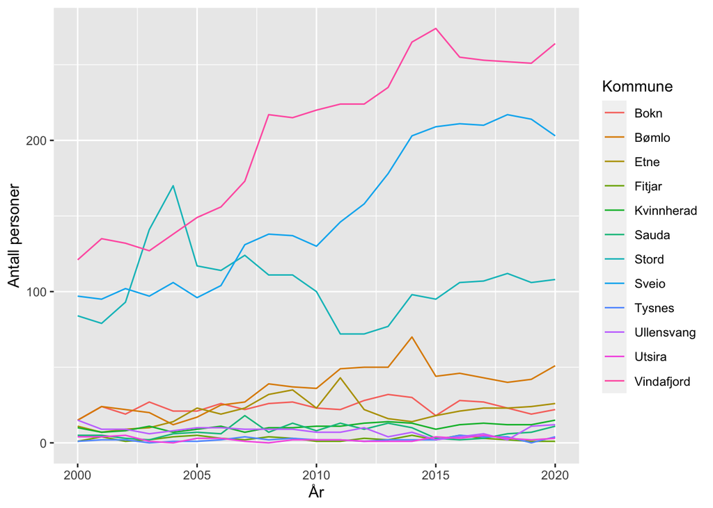

```r
Tab_03321_00_20_a %>%
  # bor i Haugesund, jobber annet sted enn Haugesund, Tysvær, Karmøy
  filter(b_knr_new == "1106" & !a_knr_new %in% c("1106", "1146", "1149")) %>%
  ggplot(mapping = aes(x = as_date(paste0(aar, "-01-01")))) +
  geom_line(mapping=aes(y = personer_new, group = a_knavn_new, colour = a_knavn_new)) +
  xlab("År") +
  ylab("Antall personer") +
  labs(colour = "Kommune")
```

# Oppgave 4

```r
library(readxl)
Tab_03321_andeler <- read_excel("Data/Tab_03321_andeler.xlsx",
    col_types = c("text", "text", "text",
        "text", "text", "numeric", "numeric",
        "numeric"))
```

# Pendler ut

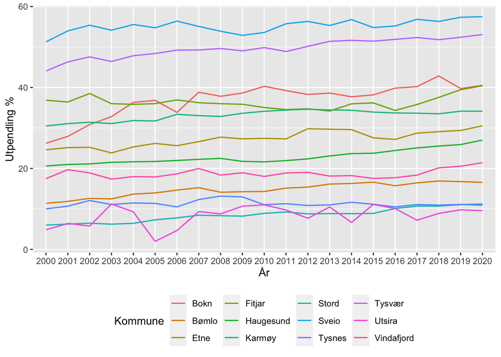

```r
#Andel pendelere ut av kommunen
Tab_03321_andeler %>%
  select(aar, b_knavn_new, Ut_pendlere) %>%
  filter(b_knavn_new %in% c("Tysvær", "Karmøy", "Haugesund", "Bokn", "Utsira", "Vindafjord", "Etne", "Sveio", "Bømlo", "Stord", "Fitjar", "Tysnes")
    ) %>%
  ggplot(mapping = aes(x = aar, y = Ut_pendlere, colour = b_knavn_new)) +
  geom_line(aes(group = b_knavn_new), lwd = 0.6) +
  theme(legend.position = 'bottom')+
  xlab("År") +
  ylab("Utpendling %") +
  labs(colour = "Kommune")
```

Det vi ser ut i fra grafen er at det er to kommuner som skiller seg klart ut når det kommer til andel utpendlere(Tysvær og Sveio). Grunnen til det er at disse kommunene er nabokommunene til Haugesund som er et arbeidssenter på haugalandet. Fitjar er også en kommune med høy andel utpendlere, grunnen til dette er litt det samme som Sveio og Tysvær, men i dette tilfelle er det Stord som arbeidssenter i sunnhordaland. Når det gjelder Bokn så er dette en liten kommune med begrenset arbeidsplasser som gir en økt utpendling til nabokommunene Karnøy, Tysvær og Haugesund.

### Utvikling over tid

Vi ser at de små kommunene svinger mye mer enn de større kommunene. De største kommunene (Haugesund og Karmøy) er ganske flate med en jevn og moderat økning. De kommunene med størst utvikling de siste 20 årene har vært Tysvær og Bokn. Tysvær er en attraktiv plass og bo fordi kvadratmeterprisen er lavere enn i Haugeusnd og reisekostnadene er overkommlige, derfor ser vi en økning i utpendlere. Når det gjelder Bokn er folketallet relativt lav, så det skal ikke store endringene til i befolkning før endringene blir radikale i utpendling. Når det gjelder resten av kommunene så er det en liten økning i alle de siste 20 årene.

# Pendler inn

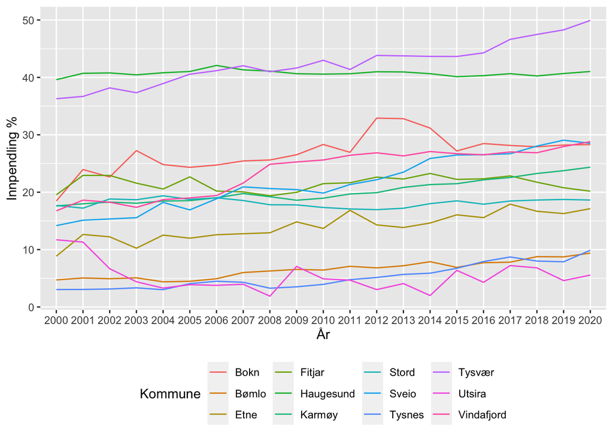

```r
#Andeler som pendler inn i kommune
Tab_03321_andeler %>%
  select(aar, b_knavn_new, Inn_pendlere) %>%
  filter(
    b_knavn_new %in% c("Tysvær", "Karmøy", "", "Haugesund", "Bokn", "Utsira", "Vindafjord", "Etne", "Sveio", "Bømlo", "Stord", "Fitjar", "Tysnes", "", "")
    ) %>%
  ggplot(mapping = aes(x = aar, y = Inn_pendlere, colour = b_knavn_new)) +
  geom_line(aes(group = b_knavn_new), lwd = 0.5) +
  theme(legend.position = 'bottom') +
  xlab("År") +
  ylab("Innpendling %") +
  labs(colour = "Kommune")
```

Tysvær er kommunen med flest andel innpendlere på grunn av kårstø og etableringer av nye næringsparker. De er også en av de kommunene som har hatt størst vekst over 20-års perioden. Haugesund har en ganske moderat og stabil vekst. Samtidig er de veldig høyt oppe i andel innpendling. Dette skyldes at Haugesund er regionens senter. Bokn sine svigninger kan skyldes Bokn Plast AS og hvordan de gjør det som privateid selskap. Dette er det største privateide selskapet i kommunen. Utsira er en kommune med veldig få antall beboere, så deres graf i figuren gir store og radikale endringer hvis for eksempel en familie skulle flyttet bort der i fra.

### Utviklingen over tid

Fleste kommuner har hatt en svak positiv utvikling. Utsira har hatt en negativ utvikling, men som nevnt er dette en kommune med svært få innbyggere.

# Bor og jobber i samme kommune

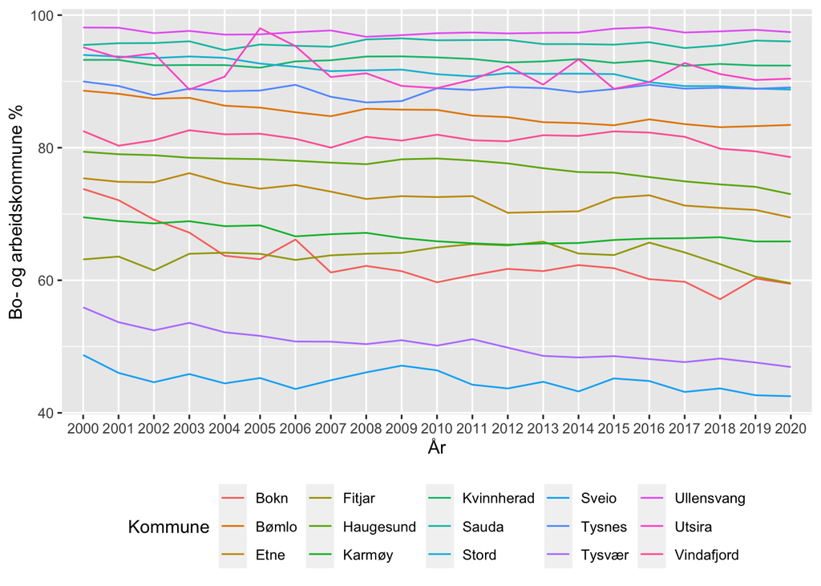

```r
Tab_03321_andeler %>%
  select(aar, b_knavn_new, b_og_a) %>%
  filter(
    b_knavn_new %in% c("Tysvær", "Karmøy", "Sauda", "Haugesund", "Bokn", "Utsira", "Vindafjord", "Etne", "Sveio", "Bømlo", "Stord", "Fitjar", "Tysnes", "Kvinnherad", "Ullensvang")
    ) %>%
  ggplot(mapping = aes(x = aar, y = b_og_a, colour = b_knavn_new)) +
  geom_line(aes(group = b_knavn_new), lwd = 0.5) +
  theme(legend.position = 'bottom')+
  xlab("År") +
  ylab("Bo- og arbeidskommune %") +
  labs(colour = "Kommune")
```

Vi ser at Sauda og Ullensvang har en stor og stabil andel av bosatte og sysselsatte innenfor samme kommune. Dette skyldes at Sauda og Odda (Odda ligger i Ullensvang), har vært byer med relativ stor industri aktivitet samtidig som de ligger relativt adskilt fra andre nære, store kommuner slik som for eksempel Haugesund og Bergen.

### Oppsummering

Pendlestrømmene øker i regionen, samtidig som vi ser at de som bor og jobber i samme kommune er avtakende i 20-års perioden.

Veinettet forbedres i tillegg til at prisene på eiendom og bolig er rimeligere per kvardratmeter utenfor de mest sentrerte plassene.

Sveio er et eksempel på hvor pendlestrømmen har økt og bosatt og sysselsatt i kommunen har synket. Sveio er en kommune med store utviklingspotensialet innenfor eiendom og bolig samtidig som avstanden til Haugesund er kort.

```r
write.csv(Tab_03321_00, "Tab_03321_00.csv")
write.csv(Tab_03321_01, "Tab_03321_01.csv")
write.csv(Tab_03321_02, "Tab_03321_02.csv")
write.csv(Tab_03321_03, "Tab_03321_03.csv")
write.csv(Tab_03321_04, "Tab_03321_04.csv")
write.csv(Tab_03321_05, "Tab_03321_05.csv")
write.csv(Tab_03321_06, "Tab_03321_06.csv")
write.csv(Tab_03321_07, "Tab_03321_07.csv")
write.csv(Tab_03321_08, "Tab_03321_08.csv")
write.csv(Tab_03321_09, "Tab_03321_09.csv")
write.csv(Tab_03321_10, "Tab_03321_10.csv")
write.csv(Tab_03321_11, "Tab_03321_11.csv")
write.csv(Tab_03321_12, "Tab_03321_12.csv")
write.csv(Tab_03321_13, "Tab_03321_13.csv")
write.csv(Tab_03321_14, "Tab_03321_14.csv")
write.csv(Tab_03321_15, "Tab_03321_15.csv")
write.csv(Tab_03321_16, "Tab_03321_16.csv")
write.csv(Tab_03321_17, "Tab_03321_17.csv")
write.csv(Tab_03321_18, "Tab_03321_18.csv")
write.csv(Tab_03321_19, "Tab_03321_19.csv")
write.csv(Tab_03321_20, "Tab_03321_20.csv")
```